# Python and R for Data Science - Task 2

Bruno Lenderink, Fabiana Caccavale, Marco Amadori

## Binance exchange

In the present report, data about the Binance on-line crypto exchange are represented.

Binance is the worlds biggest bitcoin exchange and altcoin crypto exchange in the world by volume.

## Data analysis and visualization

In order to see how volatile the Binanace bitcoin can be, the first thing to do is to compute the daily returns based in the open and close prices. To do that, the following function is used:

```r
binance$daily_return <- (binance$Close - binance$Open)/binance$Open * 100
```

The highest daily return is 22.6% and the largest drop is -39.5%. These extreme values show the volatility of the crypto.

```
##         avg      min      max
## 1 0.2661578 -39.5053 22.58318
```

The following graph represents the changes in the Binance price over time.

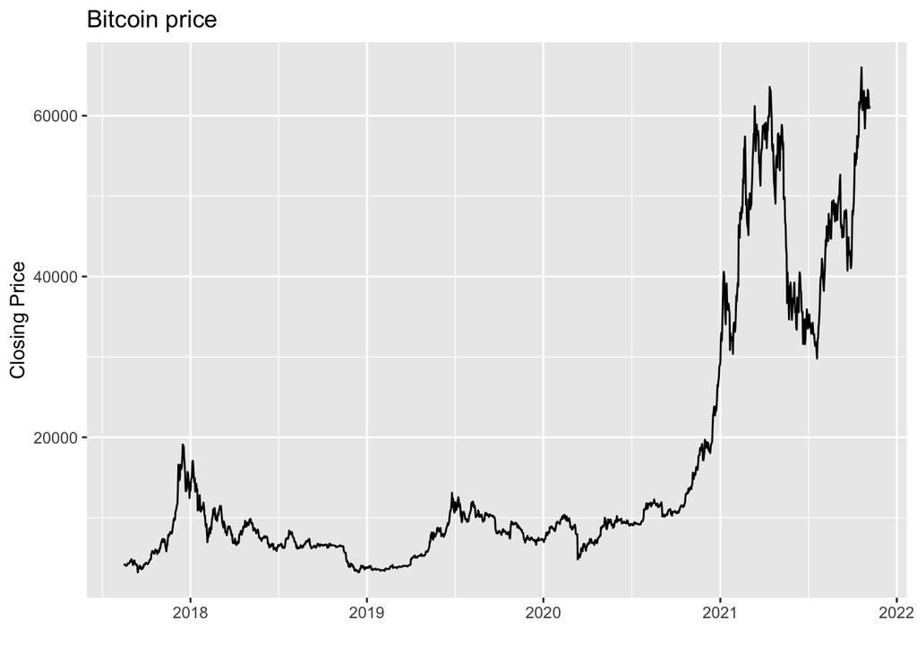

It is possible to see a large increase in the price towards the end of 2020. It further increases in 2021 but then has a large dip. Afterwards, the price increased again to an all time high of 67000.

In the graph above, 50 and 200 day simple moving averages are added to the previous graph.

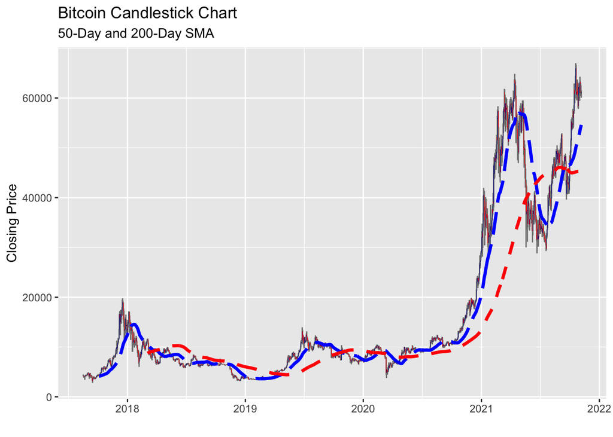

Daily trading volume is plotted in the next graph. It shows the trend over time which, on average, increases.

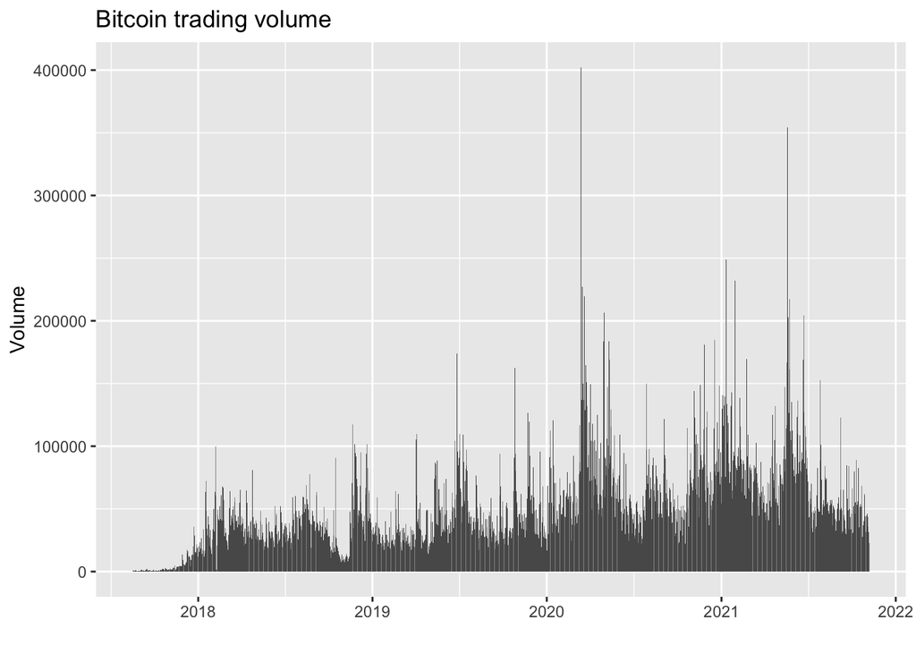

Finally, the histogram of the daily returns is shown in the following graph. We can see that they look approximately normally distributed with some extreme outliers.

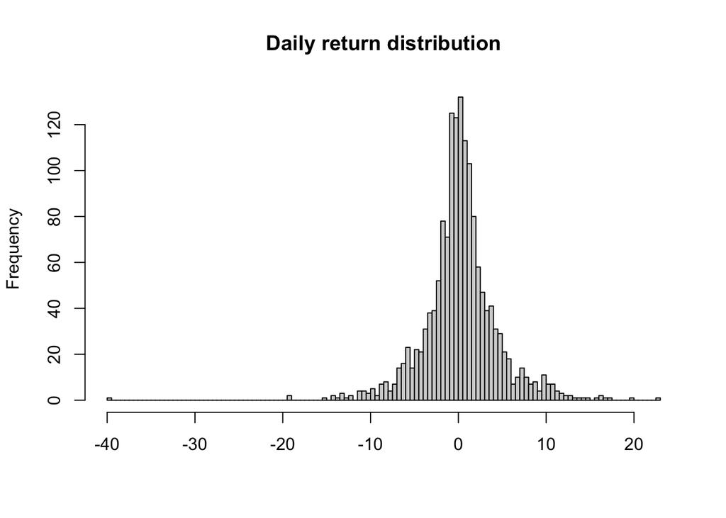

The code for the previous graphs can be found in the “Task2.R” file of the main repository.